# Trabajo Final - Introduccion a la Programacion

Joaquina Altamirano y Federico Montagna

27/09/2022

# Introducción

Los datos del presente informe fueron extraidos de la librería *“Presentes”*, cuyo objetivo es poner a disposición la información oficial sobre víctimas del terrorismo de estado entre 1966 y 1983 provista en:

http://datos.jus.gob.ar/dataset/registro-unificado-de-victimas-del-terrorismo-de-estado-ruvte  
https://www.argentina.gob.ar/sitiosdememoria/ruvte/informe  
http://basededatos.parquedelamemoria.org.ar/registros/

De la primera pagina surgen los datos sobre victimas del accionar represivo ilegal que figuran en el *Registro Unificado de Victimas del Terrorismo de Estado* (RUVTE), programa que depende del Ministerio de Justicia y Derechos Humanos de la Nacion, creado por RES N°1261/14. Segun lo indicado en la pagina web, los datos fueron publicados el 30 de septimebre de 2016 y su ultima fecha de actualizacion fu el 11 de mayo de 2022.

En esta oportunidad, a partir de los datos obetenidos de la pagina web mencionada en el parrafo anterior se construye la tabla denominada, `victimas_con_denuncia`. Cabe aclarar que, de la libreria *“Presentes”* pueden obtenerse otros datasets, igualmente valiosos, que podremos utilizar en otras instancias.

# Exploración de los datos

```r
victimas_con_denuncia <- presentes::victimas_accionar_represivo_ilegal
```

## Base `victimas_con_denuncia`

Para el presente trabajo, seleccionamos la base `victimas_con_denuncia`, la cual conforma una tabla con 21 columnas y 8753 observaciones. Las 21 columnas estan conformadas por las variables: Año en que se realiza la denuncia, tipificación según el RUVTE, nombre y apellido paterno, apellido materno, apellido de casada, edad al momento del hecho, numero de documento, año de nacimiento, provincia de nacimiento (se encuentra de dos formas, una de acuerdo al INDEC), país de nacimiento (idem), nacionalidad, embarazo, fecha de detención/secuestro, lugar de detención/secuestro, fecha del asesinato o hallazgo de restos (según corresponda), lugar de asesinato o hallazgo de restos (según corresponda).

```r
victimas_con_denuncia|>
  glimpse()
```

```
## Rows: 8,753
## Columns: 21
## $ id_unico_ruvte                       <chr> "5389", "87", "11788", "9907", "8…
## $ anio_denuncia                        <dbl> 1984, 1984, 1984, 1984, 1984, 198…
## $ tipificacion_ruvte                   <chr> "DESAPARICION FORZADA", "DESAPARI…
## $ apellido_paterno_nombres             <chr> "ABACHIAN  JUAN CARLOS", "ABAD  A…
## $ apellido_materno                     <chr> "BEDROSSIAN", "SCARLATA", "CORONE…
## $ apellido_casada                      <chr> NA, "PERUCCA", NA, NA, NA, NA, NA…
## $ edad_al_momento_del_hecho            <chr> "26 años", "24 años", "21 años", …
## $ edad_al_momento_del_hecho_numerico   <dbl> 26, 24, 21, 25, 23, 54, 23, 25, 2…
## $ documentos                           <chr> "LE 8293245", "LC 10048122", "DNI…
## $ anio_nacimiento                      <chr> "1950", "1951", "1954", "1951", "…
## $ provincia_nacimiento                 <chr> "BUENOS AIRES", "MENDOZA", "TUCUM…
## $ pais_nacimiento                      <chr> "ARGENTINA", "ARGENTINA", "ARGENT…
## $ nacionalidad                         <chr> "ARGENTINA", "ARGENTINA", "ARGENT…
## $ embarazo                             <chr> NA, NA, NA, NA, NA, NA, NA, NA, N…
## $ fecha_detencion_secuestro            <chr> "26/12/1976", "15/08/1976", "NOV/…
## $ lugar_detencion_secuestro            <chr> "LA PLATA  BUENOS AIRES", "CORDOB…
## $ fecha_asesinato_o_hallazgo_de_restos <chr> NA, NA, NA, "21/10/1976", NA, NA,…
## $ lugar_asesinato_o_hallazgo_de_restos <chr> NA, NA, NA, "GRAL. MANSILLA (BART…
## $ fotografia                           <chr> "Sí", "Sí", "No", "No", "Sí", "No…
## $ provincia_nacimiento_indec_id        <chr> "06", "50", "90", "06", "02", "90…
## $ pais_nacimiento_indec_id             <chr> "ARG", "ARG", "ARG", "ARG", "ARG"…
```

## Tomaremos para su lectura, las variables:

- Edad al momento del hecho
- Fecha de secuestro
- Fecha de asesinato o hallazgo de restos
- Embarazos

```r
victimas_con_denuncia |>
  summarise(edad_al_momento_del_hecho_numerico = mean(is.na(edad_al_momento_del_hecho_numerico)),
            fecha_detencion_secuestro = mean(is.na(fecha_detencion_secuestro)),
             fecha_asesinato_o_hallazgo_de_restos = mean(is.na(fecha_asesinato_o_hallazgo_de_restos)),
             embarazo = mean(is.na(embarazo)))|>
  pivot_longer(cols =
              c(`edad_al_momento_del_hecho_numerico`:`embarazo`),
               names_to = "Variables",
               values_to = "Proporcion_NAs")|>
gt::gt(caption = "Proporción valores faltantes")
```

Proporción valores faltantes

| Variables | Proporcion_NAs |
| --- | --- |
| edad_al_momento_del_hecho_numerico | 0.008796984 |
| fecha_detencion_secuestro | 0.129555581 |
| fecha_asesinato_o_hallazgo_de_restos | 0.724437336 |
| embarazo | 0.961727408 |

A partir de esta tabla que muestra la proporcion de valores faltantes podemos sacar las siguientes conclusiones:

1. La proporcion de datos faltantes para la variable `edad_al_momento_del_hecho_numerico` es pequeña, por lo que se entiende que su media y su desvio estandar son representativos.
2. La proporcion de datos faltantes para la variable `fecha_detencion_secuestro` es de un 12%, lo cual es un incremento importante respecto de la variable anteriormente analizada. Entendemos que esto responde a la dificultad en muchos casos de conocer la fecha exacta en la que se produjo el hecho de secuestro, desaparición o detención de las personas en cuestión.
3. La proporcion de datos faltantes para la variable `fecha_asesinato_o_hallazgo_de_restos` es de un 72%, lo cual es un incremento sustancial respecto de las variables anteriormente analizadas. Entendemos que esto responde a la dificultad en muchos casos de encontrar los restos de las personas detenidas/asesinadas/desaparecidas.
4. En el caso de la variable `embarazo` la proporción de observaciones sin información no resulta relevante, dado que no se conoce la proporción de la muestra que se encuentra en este estado.

### Edad al momento del hecho

#### Media, desvio standar y rango

```r
victimas_con_denuncia |>
  filter(!is.na(edad_al_momento_del_hecho_numerico))|>
    summarise(
    edad_media = mean(edad_al_momento_del_hecho_numerico),
    edad_sd = sd(edad_al_momento_del_hecho_numerico),
    edad_min = min(edad_al_momento_del_hecho_numerico),
    edad_max = max(edad_al_momento_del_hecho_numerico))|>
  gt::gt ()
```

| edad_media | edad_sd | edad_min | edad_max |
| --- | --- | --- | --- |
| 28.08264 | 9.549192 | 0 | 81 |

En un analisis rapido de los datos arrojados podemos ver que las victimas de secuestro y detencion ilegales durante los años 1966 y 1983 en Argentina fue una poblacion joven. Respecto del rango que adquiere esta variable, cabe mencionar que los valores mas bajos representan el secuestro de bebes y niñes.

#### Cantidad de observaciones por edad

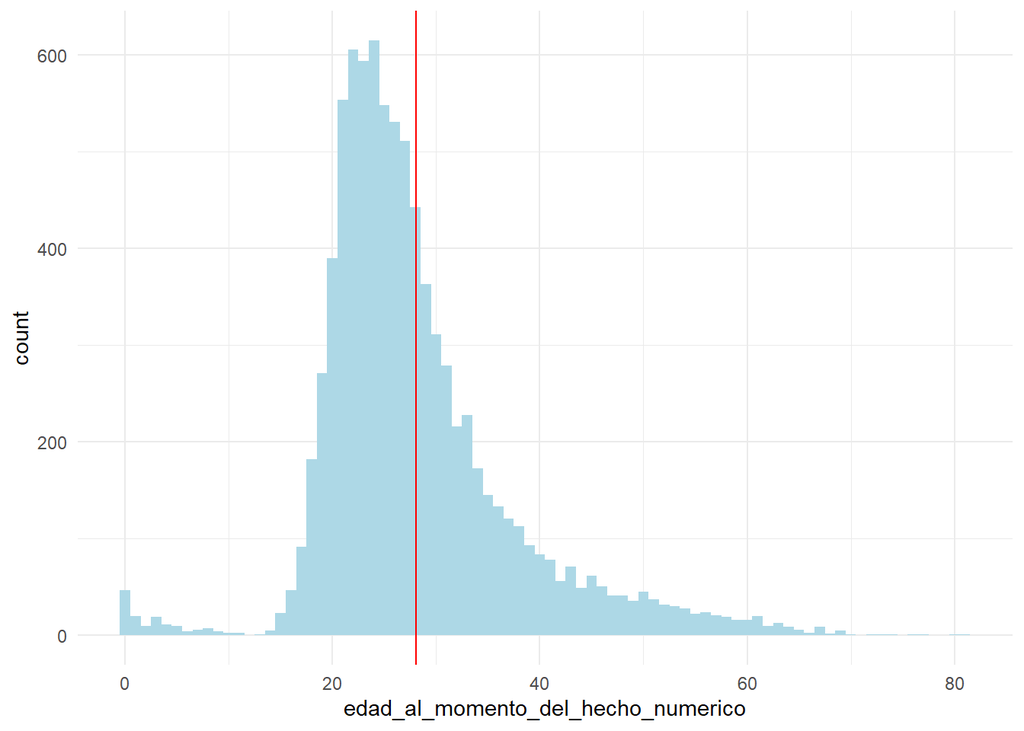

Figura 1: Observaciones por edad

```r
victimas_con_denuncia|>
  filter(!is.na(edad_al_momento_del_hecho_numerico))|>
  ggplot(aes(x = edad_al_momento_del_hecho_numerico))+
  geom_histogram(binwidth = 1, fill = "lightblue")+
  geom_vline(aes(xintercept = mean(edad_al_momento_del_hecho_numerico)),
             color = "red") +
  theme_minimal()
```

Este grafico muestra la distribucion de las edades de las personas victimas de secuestro y desaparicion forzada al momento del hecho. Además, se indica en rojo la media de la edad de las victimas.

### Fecha de secuestro

#### Rango

```r
victimas_con_denuncia|>
  summarise(fecha_min = min(fecha_detencion_secuestro),
    fecha_max = max(fecha_detencion_secuestro))|>
gt::gt(caption = "Rango: secuestros")
```

Rango: secuestros

| fecha_min | fecha_max |
| --- | --- |
| NA | NA |

De la observacion de los datos presentes en la columna fecha_detencion_secuestro surge que no todas las entradas mantienen un criterio unificado, al mismo tiempo que el tipo de variable no permite ordenar y establecer valores maximos y minimos.

#### Cantidad de observaciones por fecha de detención/secuestro

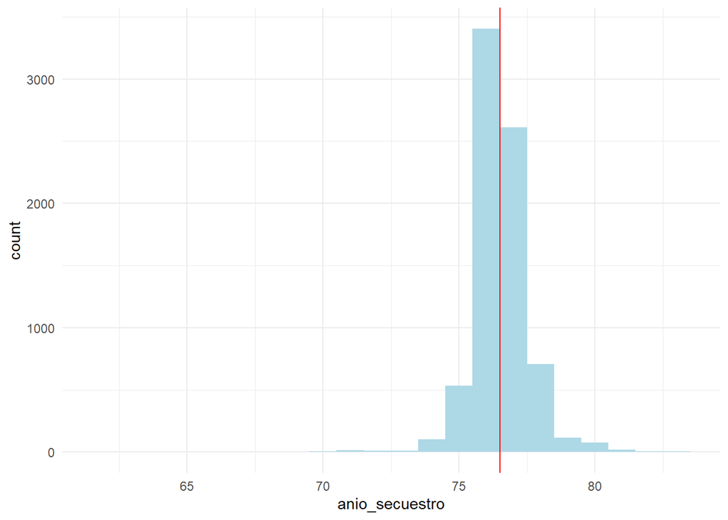

Figura 2: Observaciones por fecha de detención/secuestro

```r
victimas_con_denuncia |>
  mutate(anio_secuestro = substring(fecha_detencion_secuestro,
                                     nchar(fecha_detencion_secuestro) - 1))|>
  mutate(anio_secuestro = as.numeric(anio_secuestro))|>
  filter(!is.na(anio_secuestro))|>
  ggplot(aes(x = anio_secuestro))+
  geom_histogram(binwidth = 1, fill = "lightblue")+
  geom_vline(aes(xintercept = mean(anio_secuestro)),
             color = "red") +
  theme_minimal()
```

### Fecha de asesinato o hallazgo de restos

#### Rango

```r
victimas_con_denuncia|>
  summarise(fecha_min = min(fecha_asesinato_o_hallazgo_de_restos),
    fecha_max = max(fecha_asesinato_o_hallazgo_de_restos))|>
gt::gt()
```

| fecha_min | fecha_max |
| --- | --- |
| NA | NA |

De la observacion de los datos presentes en la columna `fecha_asesinato_o_hallazgo_de_restos` surge que no todas las entradas mantienen un criterio unificado, al mismo tiempo que el tipo de variable no permite ordenar y establecer valores maximos y minimos.

#### Cantidad de observaciones por fecha de asesinato/hallazgo del restos

```r
victimas_con_denuncia|>
  filter(!is.na(fecha_asesinato_o_hallazgo_de_restos))|>
  group_by(fecha_asesinato_o_hallazgo_de_restos)|>
  rename(Fecha = fecha_asesinato_o_hallazgo_de_restos)|>
  summarise(Cantidad = n())
```

```
## # A tibble: 881 × 2
##    Fecha         Cantidad
##    <chr>            <int>
##  1 02-05/04/1976        1
##  2 02/01/1976           1
##  3 02/01/1977           4
##  4 02/02/1976           1
##  5 02/02/1977           8
##  6 02/03/1976           1
##  7 02/03/1977           4
##  8 02/04/1976          12
##  9 02/04/1977           2
## 10 02/04/1978           3
## # … with 871 more rows
## # ℹ Use `print(n = ...)` to see more rows
```

### Embarazos

#### Cantidad de observaciones

```r
victimas_con_denuncia|>
  filter(!is.na(embarazo))|>
  group_by(embarazo)|>
  summarise(cantidad = n())|>
  gt::gt()
```

| embarazo | cantidad |
| --- | --- |
| EMBARAZADA | 284 |
| EMBARAZADA (aparentemente")" | 1 |
| EMBARAZADA (mellizos) / HIJA NACIDA EN CAUTIVERIO LOCALIZADA | 1 |
| EMBARAZADA (mellizos) / HIJOS NACIDOS EN CAUTIVERIO LOCALIZADOS | 1 |
| EMBARAZADA (probablemente")" | 1 |
| EMBARAZADA / DA A LUZ A SU HIJO SIN VIDA | 2 |
| EMBARAZADA / HIJA NACIDA EN CAUTIVERIO ENTREGADA A LA FAMILIA | 5 |
| EMBARAZADA / HIJA NACIDA EN CAUTIVERIO LOCALIZADA | 19 |
| EMBARAZADA / HIJO NACIDO EN CAUTIVERIO LOCALIZADO | 17 |
| EMBARAZADA en lugar de reclusión | 4 |

#### Embarazos por año de secuestro

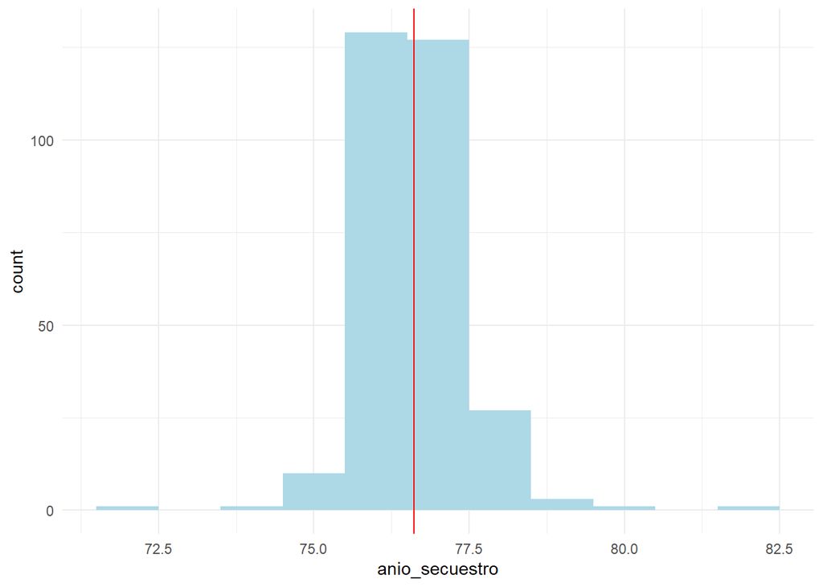

Figura 3: Embarazos por año de secuestro

```r
victimas_con_denuncia |>
  mutate(anio_secuestro = substring(fecha_detencion_secuestro,
                                     nchar(fecha_detencion_secuestro) - 1))|>
  mutate(anio_secuestro = as.numeric(anio_secuestro))|>
  mutate(emba = substring(embarazo,first = 1, last = 10))|>
  filter(!is.na(anio_secuestro) & !is.na(embarazo))|>
  ggplot(aes(x = anio_secuestro))+
  geom_histogram(binwidth = 1, fill = "lightblue")+
  geom_vline(aes(xintercept = mean(anio_secuestro)),
             color = "red")+
  theme_minimal()
```

# Hipótesis

1. Los primeros años del **Proceso de Reorganización Nacional** configuraron el momento de mayor cantidad de víctimas de procesos de detención/secuestro/desaparición.
2. En los primeros años de la dictadura civico militar se observa mayor proporción de detenciones a personas jovenes, mientras que con el transcurrir del tiempo esa edad aumenta.
3. ¿Hubo algún momento de la dictadura en la que la proporción de mujeres embarazadas detenidas-desaparecidas fue mayor?

## Hipótesis 1

*1) Los primeros años del Proceso de Reorganización Nacional configuraron el momento de mayor cantidad de víctimas de procesos de detención/secuestro/desaparición.*

### Tabla 1

```r
hipotesis_1 <- victimas_con_denuncia |>
  mutate(anio_secuestro = substring(fecha_detencion_secuestro,
                                     nchar(fecha_detencion_secuestro) - 1))|>
  mutate(anio_secuestro = as.numeric(anio_secuestro))|>
  filter(anio_secuestro >= 76 & anio_secuestro <= 83) |>
  group_by(anio_secuestro) |>
  summarise(cantidad = n()) |>
  summarise(anio_secuestro, cantidad, prop = cantidad/sum(cantidad)*100)

hipotesis_1|>
  gt::gt(caption = "Hipótesis 1: cantidad y proporcion de victimas de secuestro por año")
```

Hipótesis 1: cantidad y proporcion de victimas de secuestro por año

| anio_secuestro | cantidad | prop |
| --- | --- | --- |
| 76 | 3403 | 49.04164865 |
| 77 | 2609 | 37.59907768 |
| 78 | 708 | 10.20319931 |
| 79 | 116 | 1.67171062 |
| 80 | 74 | 1.06643609 |
| 81 | 19 | 0.27381467 |
| 82 | 6 | 0.08646779 |
| 83 | 4 | 0.05764519 |

### Gráfico 1

#### Proporción de víctimas de secuestro por año

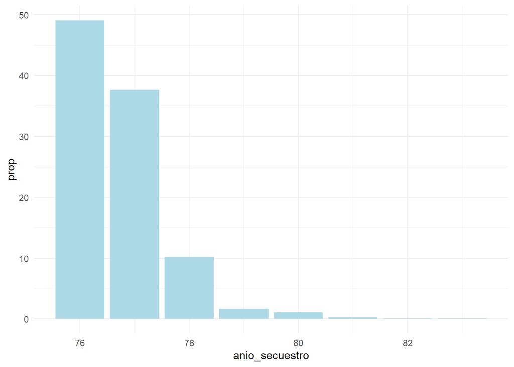

Figura 4: Proporcion victimas de secuestro por año

```r
hipotesis_1 |>
  ggplot(aes(x = anio_secuestro, y = prop))+
  geom_col(fill = "lightblue") +
  theme_minimal()
```

### Analisis Hipótesis 1

**A partir de la tabla y gráfico obtenidos, podemos concluir que la hipótesis planteada se corrobora. Vemos que el primer y segundo año del Proceso de Reorganización Nacional acumulan un total de 86% (6012 personas) de los secuestros/detenciones/desapariciones.**

## Hipótesis 2

*2) En los primeros años de la dictadura civico militar se observa mayor proporción de detenciones a personas jovenes, mientras que con el transcurrir del tiempo esa edad aumenta.*

### Tabla 2

```r
hipotesis_2 <- victimas_con_denuncia |>
  mutate(anio_secuestro = substring(fecha_detencion_secuestro,
                                     nchar(fecha_detencion_secuestro) - 1))|>
  mutate(anio_secuestro = as.numeric(anio_secuestro))|>
  filter(anio_secuestro >= 76 & anio_secuestro <= 83 & !is.na(edad_al_momento_del_hecho_numerico)) |>
  group_by(anio_secuestro) |>
  summarise(cantidad = n(), media_edad = mean(edad_al_momento_del_hecho_numerico), sd_edad = sd(edad_al_momento_del_hecho_numerico))

hipotesis_2|>
  gt::gt(caption = "Hipótesis 2: Media y desvio de la edad al momento de secuestro por año")
```

Hipótesis 2: Media y desvio de la edad al momento de secuestro por año

| anio_secuestro | cantidad | media_edad | sd_edad |
| --- | --- | --- | --- |
| 76 | 3388 | 27.98731 | 9.135248 |
| 77 | 2596 | 28.42488 | 9.629562 |
| 78 | 705 | 28.93475 | 9.115967 |
| 79 | 115 | 30.25217 | 10.819770 |
| 80 | 72 | 30.86111 | 11.301633 |
| 81 | 18 | 30.50000 | 8.452288 |
| 82 | 6 | 32.66667 | 8.189424 |
| 83 | 4 | 39.75000 | 5.123475 |

### Gráfico 2

#### Media de edad al momento del secuestro por año de secuestro

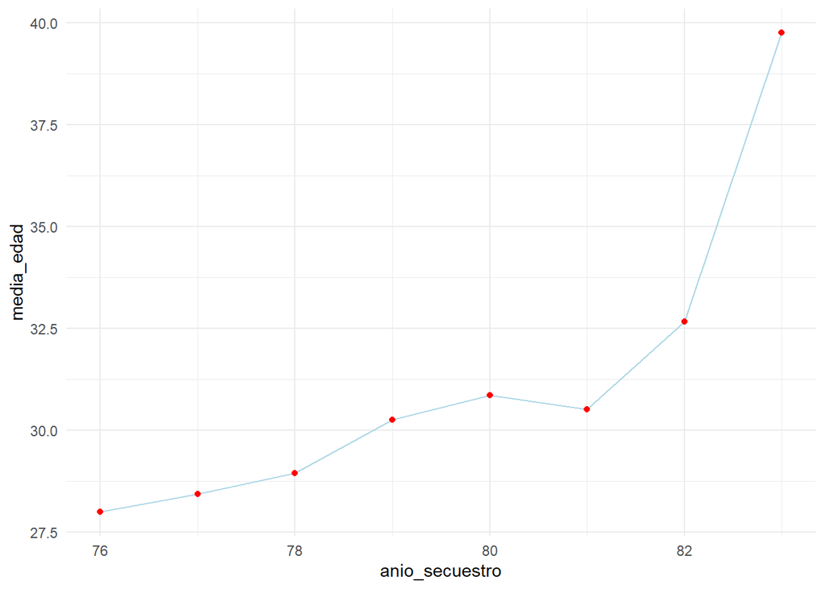

Figura 5: Media de edad al momento del secuestro por año

```r
hipotesis_2 |>
  ggplot(aes(x = anio_secuestro, y = media_edad))+
  geom_line(color = "lightblue") +
  geom_point(color = "red") +
  theme_minimal()
```

### Gráfico 3

#### Distribución de edades al momento del secuestro según año del hecho

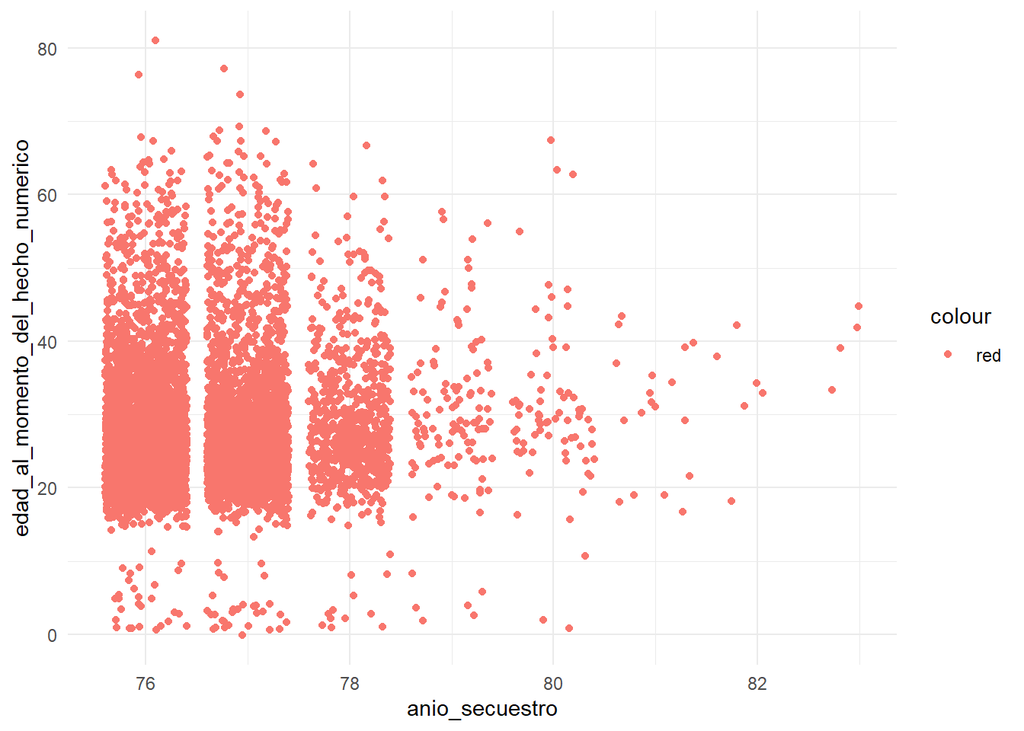

Fugura 6: Distribucion de edades segun año de secuestro

```r
victimas_con_denuncia |>
  mutate(anio_secuestro = substring(fecha_detencion_secuestro,
                                     nchar(fecha_detencion_secuestro) - 1))|>
  mutate(anio_secuestro = as.numeric(anio_secuestro))|>
  filter(anio_secuestro >= 76 & anio_secuestro <= 83 &
           !is.na(edad_al_momento_del_hecho_numerico)) |>
  ggplot(aes(x = anio_secuestro, y = edad_al_momento_del_hecho_numerico))+
  geom_jitter(aes(color = "red"))+
  theme_minimal()
```

## Hipótesis 3

*3) ¿Hubo algún momento de la dictadura en la que la proporción de mujeres embarazadas detenidas-desaparecidas fue mayor?*

### Tabla 3

```r
hipotesis_3 <- victimas_con_denuncia |>
  mutate(anio_secuestro = substring(fecha_detencion_secuestro,
                                     nchar(fecha_detencion_secuestro) - 1))|>
  mutate(anio_secuestro = as.numeric(anio_secuestro))|>
  mutate(emba = substring(embarazo,first = 1, last = 10))|>
  filter(anio_secuestro >= 76 & anio_secuestro <= 83) |>
  group_by(anio_secuestro) |>
  summarise(desap_total = n(), embarazos = sum(!is.na(emba)), prop =
              if(embarazos/desap_total*100>10) {
    NA
  }
  else embarazos/desap_total*100)

hipotesis_3|>
  gt::gt(caption = "Hipótesis 3: Proporción de victimas de secuestro que cursaban embarazos por año")
```

Hipótesis 3: Proporción de victimas de secuestro que cursaban embarazos por año

| anio_secuestro | desap_total | embarazos | prop |
| --- | --- | --- | --- |
| 76 | 3403 | 129 | 3.790773 |
| 77 | 2609 | 127 | 4.867765 |
| 78 | 708 | 27 | 3.813559 |
| 79 | 116 | 3 | 2.586207 |
| 80 | 74 | 1 | 1.351351 |
| 81 | 19 | 0 | 0.000000 |
| 82 | 6 | 1 | NA |
| 83 | 4 | 0 | 0.000000 |

### Gráfico 4

#### Proporción de víctimas de secuestro que cursaban embarazo por año

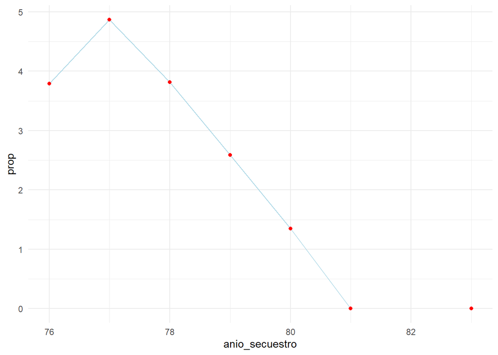

Figura 7: Proporcion de victimas que cursaban embarazo por año

```r
hipotesis_3 |>
  ggplot(aes(x = anio_secuestro, y = prop))+
  geom_line(color = "lightblue") +
  geom_point(color = "red") +
  theme_minimal()
```

Para este gráfico tomamos la decisión de sustraer el valor para el año 1982 dado que la poca cantidad de casos de desapariciones totales (6) daba por resultado un alto porcentaje de víctimas embarazadas (16%) que resulta poco representativo.

### Analisis Hipótesis 3

**A partir de la tabla y el gráfico obtenidos observamos que 1977 es el año con mayor porporción de víctimas de secuestro que cursaban (al menos aparentemente) un embarazo. Sin embargo, para calcular dicha proporción, tomamos el total de desaparecidos/as para cada año, cuando en realidad consideramos que debieran tomarse únicamente las desaparecidas mujeres, dato del que esta base de datos no dispone.**